# 1.2 — Budget Constraint — Practice Problems (Solutions)

ECON 306

You can get music via downloads ($d$) or concert tickets ($t$). You have $60 to spend each week, and the price of a download is $3 and the price of a concert ticket is $10. Put $d$ on the horizontal axis and $t$ on the vertical axis.

#### 1. Write the equation for your budget constraint.

Start with the abstract form, and then plug in the three parameters we know (price of $d$, price of $t$, and income $m)$
$$\begin{aligned}
m &= p_d d + p_t t \\
60 &= 3d + 10t \\
\end{aligned}$$

#### 2. Solve this equation for $t$, to express the equation of the line.

Solving for $t$ (on the vertical axis):

$$\begin{aligned}
\$60-\$3d&=\$10t\\
\frac{\$60}{\$10}-\frac{\$3d}{\$10}&=t\\
\$6-\frac{\$3}{\$10}d&=t\\
\end{aligned}$$

#### 3. If you spent all of your money on only Downloads, how many could you buy? If you spent all of your money only on Tickets, how many could you buy? What is the slope of your budget constraint? Graph your budget constraint.

Only on Downloads:

$$\begin{equation*}
\frac{m}{p_d}=\frac{\$60}{\$3}=20
\end{equation*}$$

Only on Tickets:

$$\begin{equation*}
\frac{m}{p_t}=\frac{\$60}{\$10}=6
\end{equation*}$$

Graph:

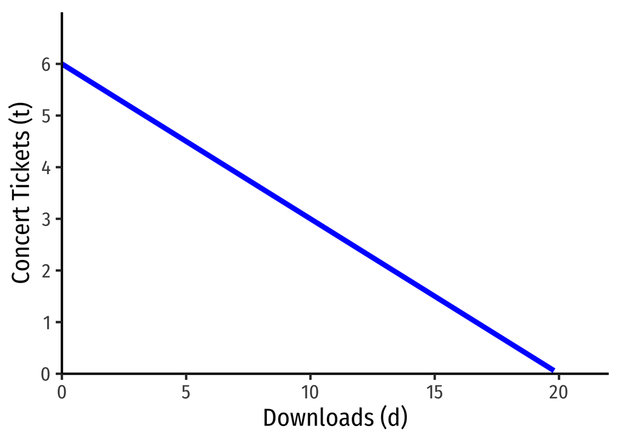

#### 4. Now suppose your income temporarily decreases to $30. Find the new equation of the budget constraint and graph it.

To do this simply, find the new intercepts, and recognize that the slope will not change!

$$\begin{equation*}
\frac{m}{p_t}=\frac{30}{10}=3
\end{equation*}$$

$$\begin{equation*}
\frac{m}{p_c}=\frac{30}{3}=10
\end{equation*}$$

$$\begin{equation*}
t=3-\frac{3}{10}d
\end{equation*}$$

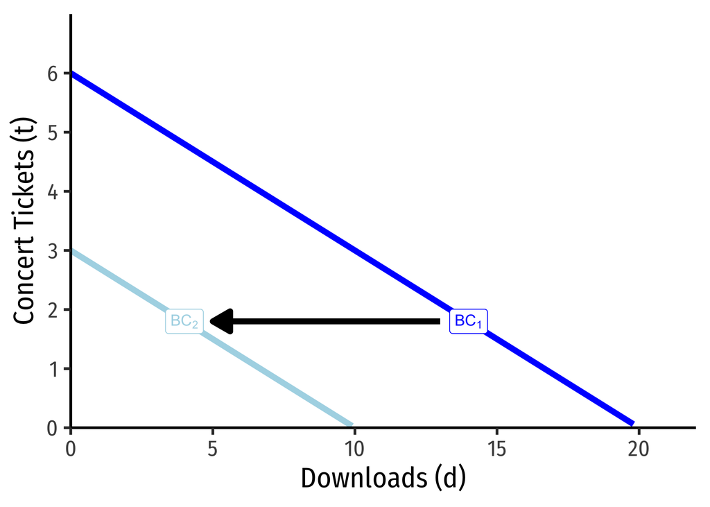

#### 5. Now return to your original income ($60) but suppose the price of downloads increases to $6. Find the new equation of the budget constraint and graph it.

Start by calculating the most downloads you could buy under the new price:

$$\begin{equation*}
\frac{m}{p_t}=\frac{\$60}{\$6}=10
\end{equation*}$$

The price of Tickets hasn’t changed, so all we do is rotate the graph with this being the new horizontal intercept.

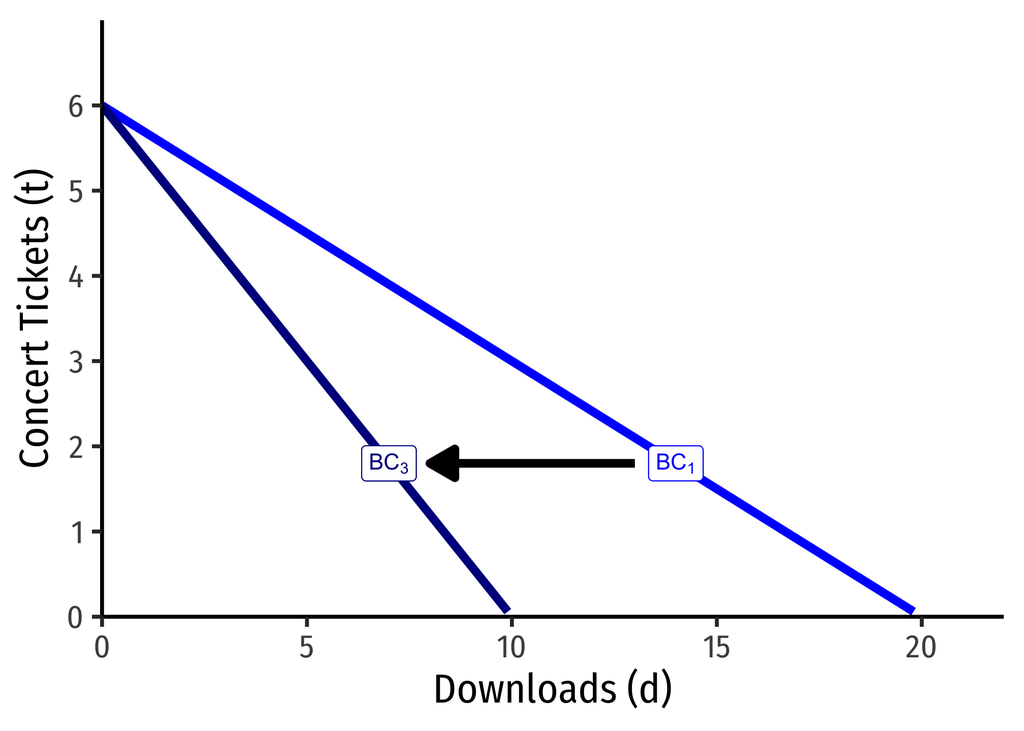